# Political Culture

POLS 2311: Government of the United States

## Agenda

- Define *political culture* and identify the core elements of American political culture
- Compare American political culture to that of other democracies
- Identify the sources of American political culture
- Evaluate conflicts within American political culture and their effect on trust and tolerance

# What do you think of when you think of the *political* culture of the United States?

# What Is Political Culture?

## Political Culture

- **Political culture**: *a patterned and sustained way of thinking about how political and economic life ought to be carried out*
- Shapes what citizens expect from government and what they consider *legitimate*
- Distinct from *political ideology*, *public opinion* and *institutions*
  - Political culture is the underlying normative environment within which they operate
- Differences among nations
  - Constitutional
  - Demographic
  - Cultural

## A Shared Culture

[figure not shown]

## The US is a Creedal Nation

- **Creedal nation**: national identity defined by shared commitment to a set of political ideals, not by ethnicity, religion, or common ancestry
- What binds Americans together isn’t a common ethnicity or ancestry but agreement on a shared set of political values
  - liberty, equality, democracy, civic duty, and individual responsibility

# Elements of the American Political System

## Five Defining Elements

- Liberty
- Equality
- Democracy
- Civic Duty
- Individual Responsibility

## Civic Duty and Civic Competence

- **Civic Duty**: a belief that one has an obligation to participate in civic and political affairs
- **Civic Competence**: a belief that one can affect government policies

# Liberal Democracy

## Liberal Democracy: A Definition

- **Liberal democracy**: a form of government that combines democratic self-rule with constitutional limits protecting individual rights against the state, and against majorities
- It blends two distinct commitments
  - **Democracy** — political authority derives from the consent of the governed, exercised through free and fair elections
  - **Liberalism** — individuals hold claims to liberty that government, and even democratic majorities, cannot legitimately override

## Institutions of Liberal Democracy

- Elections contested between distinct political parties
- Separation of powers across branches of government
- Rule of law and an independent judiciary
- Protection of individual rights and civil liberties
- Pluralism — a free press, free association, alternative sources of information
- A **market economy** — private property and competitive markets as the default system for allocating goods

## When Democracy and Liberalism Conflict

- Liberal democracy’s two halves can pull apart
- **Tyranny of the majority**: democratic majorities may use their power to oppress minorities
- **Political ignorance**: limited voter information can produce systematic errors in collective choice
- **Democratic self-destruction**: elections can bring illiberal leaders to power who then dismantle the institutions that elected them

## Liberal Democracy and Mediating Institutions

- Liberal democracy depends on **mediating institutions** between the individual and the state: family, religious congregations, civic associations, interest groups, parties, media
- These institutions produce civic trust, political information, and habits of self-governance
- Their erosion — declining social capital, shrinking civic life — threatens liberal democracy itself

# Economic Culture and Capitalism

## The American Economic System

- Americans favor *equality of opportunity* over *economic equality*
- Support of the free-enterprise system
- Tolerate economic inequality
- Value self-reliance
- Will help those “truly in need”

## Capitalism: A Definition

- **Capitalism**: an economic system based on private ownership of property and the means of production, competitive markets, and voluntary exchange for profit
- Government’s role is limited primarily to enforcing contracts and protecting property rights
- The “free enterprise system” Americans favor is capitalism in practice

# How the United States Compares

## Comparative Political Participation

- The U.S. lags behind Austria, the Netherlands, Germany, and the United Kingdom in *voter turnout*
- But Americans are as active — or substantially more active — in: campaigning, attending political meetings, community involvement, and contacting government officials

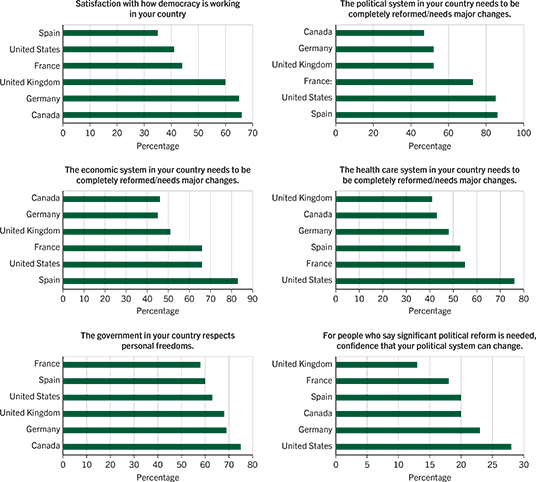

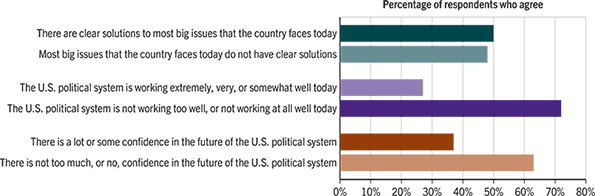

# The Civic Role of Religion

## Religion and Political Culture

- America has long been among the most religious countries in the world
- Both liberals and conservatives have used the pulpit to promote political change
- Fewer Americans are identifying with a religion
  - ~1/3 of Gen Z are religiously unaffiliated, vs. ~1/4 of Gen X and less than 1/5 of Baby Boomers

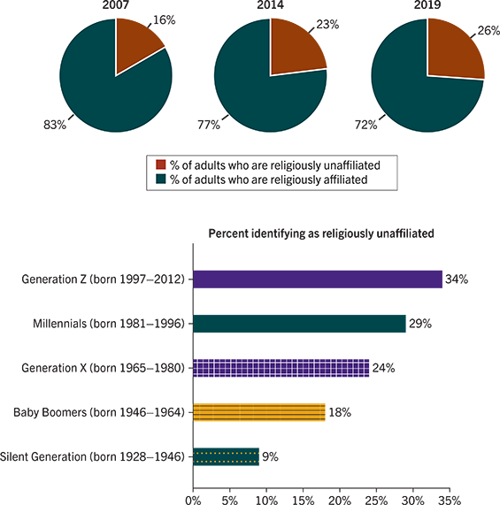

# Sources of Political Culture

## Sources

- Shared history
- Dominant religious beliefs
- Family
- What else shapes American political culture?

## Class Consciousness and the Culture War

- **Class Consciousness**: a belief that one is a member of an economic group whose interests are opposed to people in other such groups
- **Orthodox**: a belief that morality and religion ought to be of decisive importance
- **Progressive**: a belief that personal freedom and solving social problems are more important than religion
- *Culture war issues include*: abortion rights, LGBTQ+ rights, gun control, religious freedom vs. secularism, and education

# Trust, Tolerance, and Civil Society

## Mistrust of Government

- Trust in government has remained consistently below 30% since 2008
- But: survey respondents are often talking about *politicians*, not the system of government itself

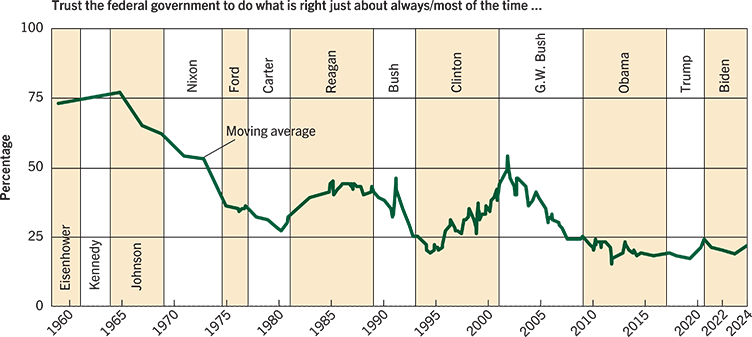

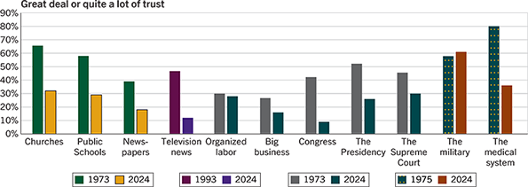

- Confidence has declined across most institutions — churches, public schools, newspapers, television news, Congress, the presidency, the Supreme Court
- The military is the sole major exception, rising over the same period

## Civil Society and Social Capital

- **Civil Society**: voluntary action that makes cooperation easier
- Americans are more likely than people in other democracies to join voluntary groups
- The more **social capital** a community has, the greater the level of trust among its members

## Civic Virtue: A Founding-Era Warning

- Benjamin Franklin: *“Only a virtuous people are capable of freedom. As nations become corrupt and vicious, they have more need of masters”* (1787)
- Tocqueville: voluntary associations train citizens in cooperation and public spirit without relying on the state
- Tocqueville’s warning of *soft despotism*: in a prosperous democracy, people may willingly trade freedom for comfort

## Political Tolerance

- Democratic politics depends on reasonable tolerance of the opinions and actions of others
- **Paradox of tolerance**: are there views that should *not* be tolerated in a free society?

[figure not shown]

## Tolerance and the Courts

- Courts are sufficiently insulated from public opinion that they can act against majority sentiments and enforce constitutional protections
- Connects to Madison and Tocqueville’s concern over *tyranny of the majority*: the danger that a democratic majority uses its power to oppress a minority